# Homework: Reading in Data

Muxin Hua

## Instructions

Big picture: Read in the Medicare and Medicaid General Payments Data and conduct an exploratory data analysis. You should use both SAS and R to explore the data, but you might choose to use R for certain tasks and SAS for other tasks.

When you are finished with the assignment:

1. Save the file as 05_Lastname_Firstname.Rmd and compile it
2. Commit the Rmd file and corresponding html file to your homework git repo
3. Push the commit to github
4. Locate the Rmd file on github and click on the SHA link for the file
5. Paste the url of the resulting page into Canvas to submit your assignment.

Your assignment must compile on a different computer as long as the saspath is set correctly for that machine. This means you will need to use a local file path when you read the data in via R (and SAS). So when you specify your file path, it should look something like “General_Payment_Data_Sample.csv” with no “/home/xxx/Documents” or “C:\” in front of it.

### About the Data

To get this data, I started with the full 2018 dataset, and limited it to cash payments made to medical doctors reported in January. The full dataset is *way* too big - several GB when stored on disk.

A sample of the full dataset is available in the template repository (and also [here](https://github.com/srvanderplas/unl-stat850/raw/master/data/General_Payment_Data_Sample.csv)). It’s 8MB after extreme trimming of the less useful columns and sampling 25% of the rows. You can read about the data [here](https://openpaymentsdata.cms.gov/about) and [here](https://www.cms.gov/openpayments/).

### Questions to Address

- Describe the dataset and any interesting parts of the data you find.
- What tasks are easier in R? SAS?
- What do you find that might need to be cleaned up or corrected before analysis?

You may want to include graphics (using the sample code in the book, or the [R Graph Gallery](https://www.r-graph-gallery.com/)) to show any interesting things you discover. When you include a graph, be sure to provide some contextual description of the information you want someone to take away from the graph.

## Data Exploration

### R

(You don’t need to keep these headings, but I want you to have a skeleton of what the code chunks should look like) #### import dataset

```r
# Read in the CSV here
payment <- read.csv('.\\General_Payment_Data_Sample.csv',
                    header = TRUE,
                    sep = ',')
head(payment)
```

```
##   Change_Type Physician_Profile_ID
## 1   UNCHANGED               219097
## 2   UNCHANGED               176033
## 3   UNCHANGED               359089
## 4   UNCHANGED               492208
## 5   UNCHANGED               249590
## 6   UNCHANGED              1249679
##   Recipient_Primary_Business_Street_Address_Line1 Recipient_City
## 1                                   1840 MEASE DR  SAFETY HARBOR
## 2                               200 E Chestnut St     Louisville
## 3                                450 CLARKSON AVE       BROOKLYN
## 4                              1510 S CENTRAL AVE       GLENDALE
## 5                                6780 INDIANA AVE      RIVERSIDE
## 6                                   818 W King St         Owosso
##   Recipient_State Recipient_Zip_Code Recipient_Country Recipient_Province
```

[output cut: 139 more lines]

#### describe the dataset

We first want to know the dimension of the data, and the data types of the variables.

```r
summary(payment)
```

```
##  Change_Type        Physician_Profile_ID
##  Length:22302       Min.   :     24
##  Class :character   1st Qu.: 124415
##  Mode  :character   Median : 244590
##                     Mean   : 411508
##                     3rd Qu.: 366647
##                     Max.   :5705345
##  Recipient_Primary_Business_Street_Address_Line1 Recipient_City
##  Length:22302                                    Length:22302
##  Class :character                                Class :character
##  Mode  :character                                Mode  :character
##
##
##
##  Recipient_State    Recipient_Zip_Code Recipient_Country  Recipient_Province
##  Length:22302       Length:22302       Length:22302       Length:22302
##  Class :character   Class :character   Class :character   Class :character
##  Mode  :character   Mode  :character   Mode  :character   Mode  :character
##
##
##
##  Recipient_Postal_Code Physician_Specialty
##  Length:22302          Length:22302
##  Class :character      Class :character
##  Mode  :character      Mode  :character
##
##
##
##  Submitting_Applicable_Manufacturer_or_Applicable_GPO_Name
##  Length:22302
##  Class :character
##  Mode  :character
##
##
##
##  Applicable_Manufacturer_or_Applicable_GPO_Making_Payment_ID
##  Min.   :1e+11
##  1st Qu.:1e+11
##  Median :1e+11
##  Mean   :1e+11
```

[output cut: 92 more lines]

```
##
##  Name_of_Drug_or_Biological_or_Device_or_Medical_Supply_1
##  Length:22302
##  Class :character
##  Mode  :character
##
##
##
##  Associated_Drug_or_Biological_NDC_1
##  Length:22302
##  Class :character
##  Mode  :character
##
##
##
```

```r
dim(payment)[1]
```

```
## [1] 22302
```

This is a dataset with 34 columns and 22302 rows and most of them are categorical data.

#### *Not-a-number* values

Taking a look at the data to see if there is any *Not-a-number* value. If there are some NA’s, we have to take actions to these value.

```r
sum(is.na(payment))
```

```
## [1] 0
```

From this result, it looks like there is no NA in the data set, which is uncommon for data collected from medical doctors. So I would take a closer look at the data.

```r
library(dplyr)
```

```r
library(ggplot2)
change_types <- payment %>% group_by(Change_Type) %>% summarize(n=n())
```

#### Take a look at the distribution of *Applicable_Manufacturer_or_Applicable_GPO_Making_Payment_State*.

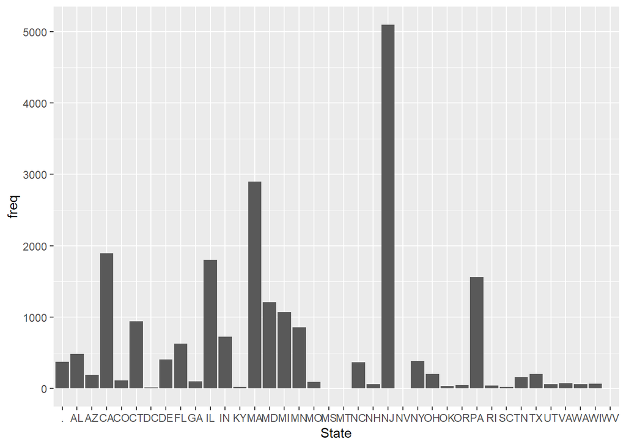

```r
state <- payment %>% group_by(Applicable_Manufacturer_or_Applicable_GPO_Making_Payment_State) %>% summarize(freq=n())

ggplot(data=state, aes(Applicable_Manufacturer_or_Applicable_GPO_Making_Payment_State, freq))+
  geom_col()+
  labs(x='State')
```

New Jersey has the most frequency in Applicable Manufacturer or Applicable GPO Making Payment. The rest of the top 5 are Massachusetts, California, Pennsylvania and Illinois. But there is a portion of data classified as ‘.’, we need to figure out how large is the portion to decide what we should do about these data (remove or trace back and etc.)

```r
state$state <- state$Applicable_Manufacturer_or_Applicable_GPO_Making_Payment_State
state <- state[,-1]
NA_ratio <- state[state$state=='.',][1,1]/sum(state$freq)
NA_ratio
```

```
##     freq
## 1 0.0166
```

There are 1.66% missing data in *Applicable_Manufacturer_or_Applicable_GPO_Making_Payment_State*. This is not a very large portion, so we could remove it for further analyse.

```r
#remove the NA data
payment <- payment[(payment$Applicable_Manufacturer_or_Applicable_GPO_Making_Payment_State!='.'),]
```

#### Check *NA* for other variables

```r
head(payment)
```

```
##   Change_Type Physician_Profile_ID
## 1   UNCHANGED               219097
## 2   UNCHANGED               176033
## 3   UNCHANGED               359089
## 4   UNCHANGED               492208
## 5   UNCHANGED               249590
## 6   UNCHANGED              1249679
##   Recipient_Primary_Business_Street_Address_Line1 Recipient_City
## 1                                   1840 MEASE DR  SAFETY HARBOR
## 2                               200 E Chestnut St     Louisville
## 3                                450 CLARKSON AVE       BROOKLYN
## 4                              1510 S CENTRAL AVE       GLENDALE
## 5                                6780 INDIANA AVE      RIVERSIDE
## 6                                   818 W King St         Owosso
##   Recipient_State Recipient_Zip_Code Recipient_Country Recipient_Province
```

[output cut: 139 more lines]

```r
payment %>% group_by(Recipient_Province) %>% summarize(freq=n())
```

```
## # A tibble: 2 x 2
##   Recipient_Province  freq
##   <chr>              <int>
## 1 .                  21930
## 2 BRITISH COLUMBIA       1
```

```r
payment %>% group_by(Recipient_Postal_Code) %>% summarize(freq=n())
```

```
## # A tibble: 2 x 2
##   Recipient_Postal_Code  freq
##   <chr>                 <int>
## 1 .                     21930
## 2 V4E2Z6                    1
```

```r
payment %>% group_by(City_of_Travel) %>% summarize(freq=n())
```

```
## # A tibble: 707 x 2
##    City_of_Travel  freq
##    <chr>          <int>
##  1 .              19503
##  2 Aberdeen           1
##  3 ACWORTH            1
##  4 ADA                1
##  5 AGAWAM             1
##  6 Alameda            2
##  7 Albany             5
##  8 ALBANY             3
##  9 ALBEMARLE          1
## 10 ALBUQUERQUE        2
## # ... with 697 more rows
```

```r
payment %>% group_by(State_of_Travel) %>% summarize(freq=n())
```

```
## # A tibble: 51 x 2
##    State_of_Travel  freq
##    <chr>           <int>
##  1 .               19607
##  2 AK                  2
##  3 AL                 13
##  4 AR                  3
##  5 AZ                104
##  6 CA                368
##  7 CO                 39
##  8 CT                 21
##  9 DC                 15
## 10 DE                  4
## # ... with 41 more rows
```

```r
payment %>% group_by(Country_of_Travel) %>% summarize(freq=n())
```

```
## # A tibble: 32 x 2
##    Country_of_Travel  freq
##    <chr>             <int>
##  1 .                 19503
##  2 Argentina             1
##  3 Australia             3
##  4 Austria               3
##  5 Belgium               4
##  6 Brazil                2
##  7 Cambodia              1
##  8 Canada               16
##  9 China                 6
## 10 Colombia              2
## # ... with 22 more rows
```

```r
payment %>% group_by(Name_of_Third_Party_Entity_Receiving_Payment_or_Transfer_of_Value) %>% summarize(freq=n())
```

```
## # A tibble: 735 x 2
##    Name_of_Third_Party_Entity_Receiving_Payment_or_Transfer_of_Value  freq
##    <chr>                                                             <int>
##  1 .                                                                 20845
##  2 1995 LLC                                                              1
##  3 2 In Space and Time                                                   1
##  4 6C, LLC                                                               1
##  5 A AND B MEDICAL LLC                                                   2
##  6 ABD Insurance                                                         1
##  7 Abel Brown                                                            1
##  8 Adam Ashton, M.D.                                                     1
##  9 Adult  Pediatric Dermatology                                          1
## 10 Adult and Pediatric Dermatology                                       4
## # ... with 725 more rows
```

```r
payment %>% group_by(Third_Party_Equals_Covered_Recipient_Indicator) %>% summarize(freq=n())
```

```
## # A tibble: 3 x 2
##   Third_Party_Equals_Covered_Recipient_Indicator  freq
##   <chr>                                          <int>
## 1 .                                              20721
## 2 No                                              1009
## 3 Yes                                              201
```

```r
payment %>% group_by(Contextual_Information) %>% summarize(freq=n())
```

```
## # A tibble: 451 x 2
##    Contextual_Information                           freq
##    <chr>                                           <int>
##  1 .                                               20647
##  2 ;GSQNTJPVSYVCJ;AHM;10589589;VPL NAME AND SLN        1
##  3 ;GSQNZLXRUTPJ0;AHM;10149838;VPL NAME AND SLN        1
##  4 ;GSQO4Q19W9BBH;AHM;10893093;NPPES NAME AND SLN      1
##  5 ;GSQO5U4070KNR;SCIM;10144223;NPPES NAME AND SLN     1
##  6 ;GSQO5U4070KNX;SCIM;10628355;VPL NAME AND SLN       1
##  7 ;GSQO5U4070KNZ;SCIM;10583745;VPL NAME AND SLN       1
##  8 ;GSQO5U4070KO0;SCIM;12777609;VPL NAME AND SLN       1
##  9 ;GSQO5U4070KO1;SCIM;10002216;VPL NAME AND SLN       1
## 10 ;GSQO5U4070KO9;SCIM;10428878;VPL NAME AND SLN       1
## # ... with 441 more rows
```

```r
payment %>% group_by(Charity_Indicator) %>% summarize(freq=n())
```

```
## # A tibble: 3 x 2
##   Charity_Indicator  freq
##   <chr>             <int>
## 1 .                 13720
## 2 No                 8199
## 3 Yes                  12
```

```r
payment %>% group_by(Associated_Drug_or_Biological_NDC_1) %>% summarize(freq=n())
```

```
## # A tibble: 370 x 2
##    Associated_Drug_or_Biological_NDC_1  freq
##    <chr>                               <int>
##  1 .                                    9942
##  2 0002-1433-80                           66
##  3 0002-1445-11                           37
##  4 0002-6216-54                            1
##  5 0002-7623-01                            1
##  6 0002-7669-01                            1
##  7 0002-8315-01                           11
##  8 0003-0215-01                            1
##  9 0003-0857-22                           57
## 10 0003-0893-21                           17
## # ... with 360 more rows
```

```r
payment <- payment[,-which(colnames(payment) %in% c('Recipient_Province', 'Recipient_Postal_Code', 'City_of_Travel', 'State_of_Travel', 'Country_of_Travel', 'Name_of_Third_Party_Entity_Receiving_Payment_or_Transfer_of_Value', 'Third_Party_Equals_Covered_Recipient_Indicator', 'Contextual_Information', 'Charity_Indicator', 'Associated_Drug_or_Biological_NDC_1'))]
```

### Data type changing

#### Fix zip code

I’ll keep the first 5 digits only.

```r
payment$Recipient_Zip_Code <- substr(payment[, 'Recipient_Zip_Code'],1,5)
```

#### Change the data type of *Date_of_Payment* to date type

```r
library(lubridate)
payment$Payment_date <- mdy(payment$Date_of_Payment)
```

#### Prepare data for SAS

```r
payment %>% sample_frac(size= .25) %>% write.csv('C:\\Users\\HUA\\Documents\\2021\\850\\05-reading-in-data-Muxin_Hua\\cleaned_payment.csv', na='.')
```

#### Do some Plots

> 1, Look at the change type distribution for different change type.

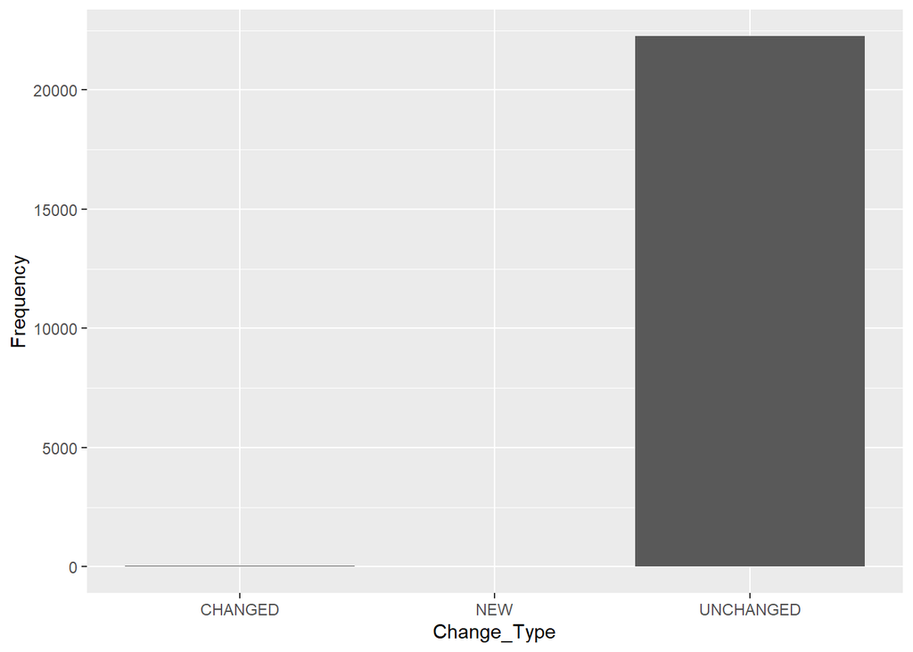

```r
ggplot(data=change_types, aes(Change_Type, n))+
  geom_col()+
  labs(y='Frequency')
```

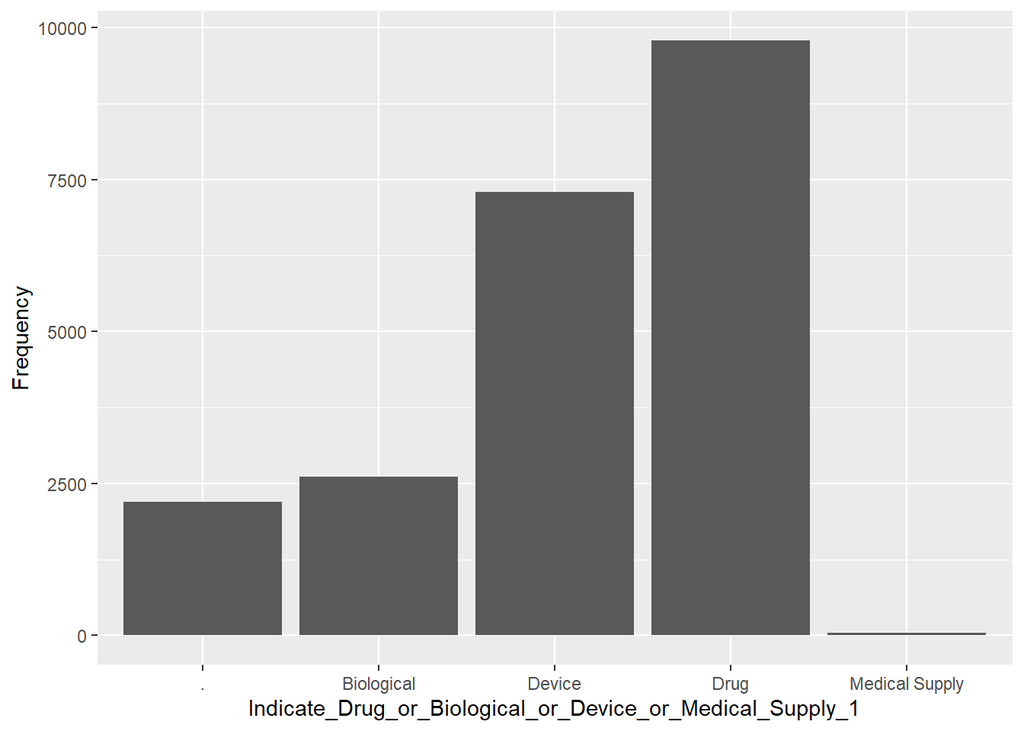

```r
cover_types <- payment %>% group_by(Indicate_Drug_or_Biological_or_Device_or_Medical_Supply_1) %>% summarize(n1=n())
ggplot(data=cover_types, aes(Indicate_Drug_or_Biological_or_Device_or_Medical_Supply_1, n1))+
  geom_col()+
  labs(y='Frequency')
```

>2, Payment amount by state  
We may want to know which state paied most.

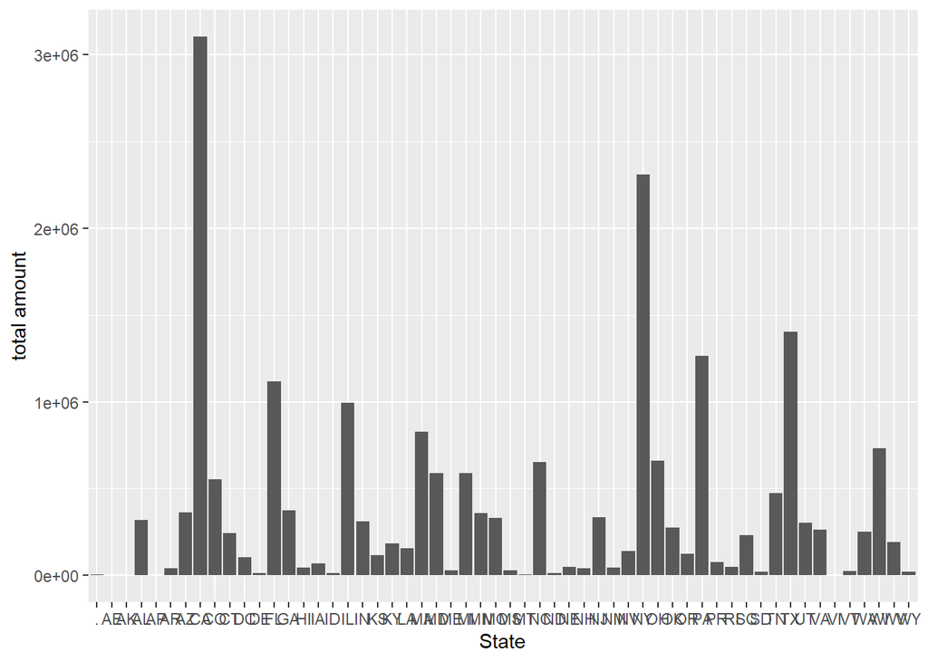

```r
pay_state <- data.frame(payment[,'Total_Amount_of_Payment_USDollars'],payment[,'Recipient_State'])
colnames(pay_state) <- c('pay', 'state')
new <- aggregate(pay_state$pay,by=list(type=pay_state$state),sum)

ggplot(new, aes(type, x))+
  geom_col()+
  labs(x='State', y='total amount')
```

> 3, payment times vs date

```r
library(lubridate)
date <- payment %>% group_by(Date_of_Payment) %>% summarize(freq=n())

date$dat <- mdy(date$Date_of_Payment)
date
```

```
## # A tibble: 31 x 3
##    Date_of_Payment  freq dat
##    <chr>           <int> <date>
##  1 01/01/2018        165 2018-01-01
##  2 01/02/2018        455 2018-01-02
##  3 01/03/2018        800 2018-01-03
##  4 01/04/2018        708 2018-01-04
##  5 01/05/2018        733 2018-01-05
##  6 01/06/2018        359 2018-01-06
##  7 01/07/2018         56 2018-01-07
##  8 01/08/2018        798 2018-01-08
##  9 01/09/2018        924 2018-01-09
## 10 01/10/2018       1060 2018-01-10
## # ... with 21 more rows
```

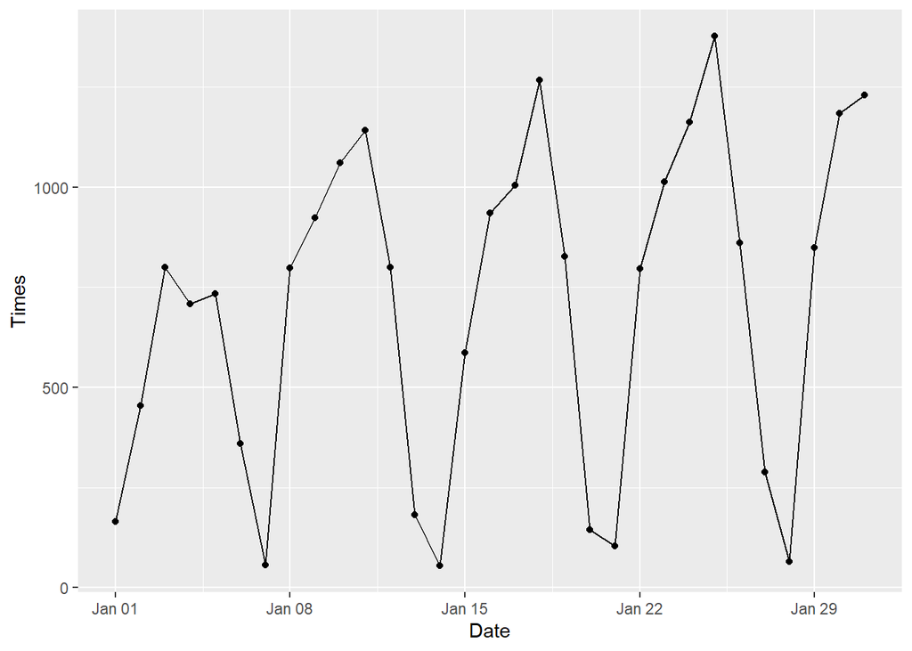

```r
ggplot(data=date, aes(dat, freq))+
  geom_point()+
  geom_line()+
  xlab('Date')+
  ylab('Times')
```

From this plot of payment times vs Date, we can see a periodic pattern in the payment times along with date. There might be a period and a reason behind that, which could be a leading question for further analysis.

### Answers for the Questions

#### What tasks are easier in R? SAS?

> I would say most of the wrangling work are easier in R, because R has a straight forward syntax, and much easier to visualize the data-changing. 2-D plot is also easier in R due to the abundant packages offer in R. But when it comes to the statistical result, there’s no doubt SAS gives more clear, detailed results.

#### What do you find that might need to be cleaned up or corrected before analysis?

> There are several kinds of data need to be cleaned up. 1, NA data. NA data usually gives unclear and misleading statistic result, so i would recommend clean these data first. 2, time format data. Time is quit special as it has its own data format. Considering chronogical effect normally gets more attention, correct data for time is important. 3, abnormal data. I would suggest taking a brief look at the data (mean, min. max etc.), so one could have a first impression of the data, and maybe spot some abonormal data. For example negative value for payment, or several extremly small data in a column where the rest are more than 100 times of these extrmlly small ones, the same idea applies for extremly large data.